# Jaccard Index for PTMs

Adam Martí García

2024-11-16

Load necessary libraries and file paths.

```r
library(dplyr)
```

```r
library(tidyr)
library(purrr)
library(stringr)
library(pheatmap)

setwd("~/Desktop/PGB/PGB_FINAL_PROJECT")
ptm_data <- read.csv("~/Desktop/PGB/PGB_FINAL_PROJECT/PTMs_Atoh1.csv", stringsAsFactors = FALSE) #This is a file that contains all the different PTMs by position for each of the paralogous genes, and also if they are or not on the bHLH domain.
ptm_length <- read.csv("~/Desktop/PGB/PGB_FINAL_PROJECT/PTMs_gene_lenghts.csv") #This is a file that contains the different protein lengths encoded by each of the paralogous genes.
head(ptm_data)
```

```
##    Gene Modification bHLH  X X.1 X.2 X.3 X.4 X.5 X.6 X.7 X.8
## 1 Atoh1        Y49-p   No NA  NA  NA  NA  NA  NA  NA  NA  NA
## 2 Atoh1        Y80-p   No NA  NA  NA  NA  NA  NA  NA  NA  NA
## 3 Atoh1        S84-p   No NA  NA  NA  NA  NA  NA  NA  NA  NA
## 4 Atoh1       S109-p   No NA  NA  NA  NA  NA  NA  NA  NA  NA
## 5 Atoh1       S110-p   No NA  NA  NA  NA  NA  NA  NA  NA  NA
## 6 Atoh1       S150-p   No NA  NA  NA  NA  NA  NA  NA  NA  NA
```

```r
head(ptm_length)
```

```
##      GENE LENGTH
## 1   Atoh1    354
## 2   Atoh7    152
## 3   Atoh8    321
## 4 BHLHA15    189
## 5 BHLHE22    381
## 6 BHLHE23    241
```

Define the function for splitting the residue modification. For how is the .csv document, we need to split into different columns the modification type and the position.

```r
# Function to parse the modification string
parse_modification <- function(modification) {
  print(paste("Processing:", modification)) # Debugging print statement

  # Ensure the input is a single string and trim spaces
  modification <- trimws(as.character(modification))

  if (is.na(modification) || modification == "") {
    return(list(Residue = NA, Position = NA, Modification = NA))
  }

  # Extract the residue (first character)
  residue <- str_sub(modification, 1, 1)

  # Extract the position (numbers)
  position <- str_extract(modification, "\\d+")

  # Extract the modification type (if present)
  mod_type <- str_extract(modification, "-[a-z]+$")

  # Return a list with extracted components
  return(list(
    Residue = residue,
    Position = as.numeric(position),
    Modification = mod_type
  ))
}
```

Next, we apply the function to the data

```r
# Confirm the column name
corrected_column <- "Modification"  # Adjust based on your actual column name

# Check if the column exists and contains data
print("Initial data in the Modification column:")
```

```
## [1] "Initial data in the Modification column:"
```

```r
print(head(ptm_data[[corrected_column]]))
```

```
## [1] "Y49-p"  "Y80-p"  "S84-p"  "S109-p" "S110-p" "S150-p"
```

```r
# Apply the parse_modification function row-wise
ptm_data_parsed <- ptm_data %>%
  mutate(parsed_info = map(!!sym(corrected_column), parse_modification)) %>%
  unnest_wider(parsed_info, names_sep = "_")
```

[output not shown]

[output cut: 91 more lines]

```r
# Display the resulting data frame after parsing
print("Data after applying parse_modification and unnest_wider:")
```

```
## [1] "Data after applying parse_modification and unnest_wider:"
```

```r
print(head(ptm_data_parsed))
```

```
## # A tibble: 6 × 15
##   Gene  Modification bHLH  X     X.1   X.2   X.3   X.4   X.5   X.6   X.7   X.8
##   <chr> <chr>        <chr> <lgl> <lgl> <lgl> <lgl> <lgl> <lgl> <lgl> <lgl> <lgl>
## 1 Atoh1 Y49-p        No    NA    NA    NA    NA    NA    NA    NA    NA    NA
## 2 Atoh1 Y80-p        No    NA    NA    NA    NA    NA    NA    NA    NA    NA
## 3 Atoh1 S84-p        No    NA    NA    NA    NA    NA    NA    NA    NA    NA
## 4 Atoh1 S109-p       No    NA    NA    NA    NA    NA    NA    NA    NA    NA
## 5 Atoh1 S110-p       No    NA    NA    NA    NA    NA    NA    NA    NA    NA
## 6 Atoh1 S150-p       No    NA    NA    NA    NA    NA    NA    NA    NA    NA
## # ℹ 3 more variables: parsed_info_Residue <chr>, parsed_info_Position <dbl>,
## #   parsed_info_Modification <chr>
```

```r
# Remove any extra unwanted columns
# Explicitly select only the columns you need
ptm_data_parsed <- ptm_data_parsed %>%
  dplyr::select(Gene, Modification, bHLH, parsed_info_Residue, parsed_info_Position, parsed_info_Modification)

# Print the final result
print("Final data:")
```

```
## [1] "Final data:"
```

```r
print(ptm_data_parsed)
```

```
## # A tibble: 106 × 6
##    Gene  Modification bHLH  parsed_info_Residue parsed_info_Position
##    <chr> <chr>        <chr> <chr>                              <dbl>
##  1 Atoh1 Y49-p        No    Y                                     49
##  2 Atoh1 Y80-p        No    Y                                     80
##  3 Atoh1 S84-p        No    S                                     84
##  4 Atoh1 S109-p       No    S                                    109
##  5 Atoh1 S110-p       No    S                                    110
##  6 Atoh1 S150-p       No    S                                    150
##  7 Atoh1 S196-p       Yes   S                                    196
##  8 Atoh1 S312-p       No    S                                    312
##  9 Atoh1 S314-p       No    S                                    314
## 10 Atoh1 S328-p       No    S                                    328
## # ℹ 96 more rows
## # ℹ 1 more variable: parsed_info_Modification <chr>
```

Next, positions of each of the modifications must be normalized, because all the different proteins have different lengths, and a modification on position 54 of NEUROD2 is not the same that for NEUROG1. Thus, positions are normalized by percentile (this is, the new position will be presented as positionof PTM/length of the protein).

```r
# Check the contents of the lengths data
print(ptm_length)
```

```
##       GENE LENGTH
## 1    Atoh1    354
## 2    Atoh7    152
## 3    Atoh8    321
## 4  BHLHA15    189
## 5  BHLHE22    381
## 6  BHLHE23    241
## 7  NEUROD2    382
## 8  NEUROD1    356
## 9  NEUROD4    331
## 10 NEUROD6    337
## 11    NGN1    237
## 12    NGN2    272
## 13    NGN3    214
## 14   OLIG1    271
## 15   OLIG2    323
## 16   OLIG3    272
```

```r
# Ensure the column names are correctly identified
lengths_data <- ptm_length %>%
  rename(Gene = GENE, Length = LENGTH)

# Merge lengths data with the parsed modifications data
ptm_data_parsed <- ptm_data_parsed %>%
  left_join(lengths_data, by = "Gene")

# Normalize the modification positions
ptm_data_parsed <- ptm_data_parsed %>%
  mutate(Normalized_Position = (parsed_info_Position / Length) * 100)

# Display the resulting data frame with normalized positions
print(ptm_data_parsed)
```

```
## # A tibble: 106 × 8
##    Gene  Modification bHLH  parsed_info_Residue parsed_info_Position
##    <chr> <chr>        <chr> <chr>                              <dbl>
##  1 Atoh1 Y49-p        No    Y                                     49
##  2 Atoh1 Y80-p        No    Y                                     80
##  3 Atoh1 S84-p        No    S                                     84
##  4 Atoh1 S109-p       No    S                                    109
##  5 Atoh1 S110-p       No    S                                    110
##  6 Atoh1 S150-p       No    S                                    150
##  7 Atoh1 S196-p       Yes   S                                    196
##  8 Atoh1 S312-p       No    S                                    312
##  9 Atoh1 S314-p       No    S                                    314
## 10 Atoh1 S328-p       No    S                                    328
## # ℹ 96 more rows
## # ℹ 3 more variables: parsed_info_Modification <chr>, Length <int>,
## #   Normalized_Position <dbl>
```

Now we are going to try it by separating the modifications in bHLH and the ones that are not, trying thus to capture the possible different level of conservation between a pretty-well structured region on the proteins and the rest of the sequences. Also, we only focus on S and T modifications

```r
# Filter modifications for Serine (S) and Threonine (T) with bHLH == "No"
ptm_data_non_bHLH_ST <- ptm_data_parsed %>%
  filter(parsed_info_Residue %in% c("S", "T"), bHLH == "No")

# Filter modifications for Serine (S) and Threonine (T) with bHLH == "Yes"
ptm_data_bHLH_ST <- ptm_data_parsed %>%
  filter(parsed_info_Residue %in% c("S", "T"), bHLH == "Yes")

# Display the results to confirm
print("Non-bHLH domain modifications for S and T:")
```

```
## [1] "Non-bHLH domain modifications for S and T:"
```

```r
print(ptm_data_non_bHLH_ST)
```

```
## # A tibble: 61 × 8
##    Gene  Modification bHLH  parsed_info_Residue parsed_info_Position
##    <chr> <chr>        <chr> <chr>                              <dbl>
##  1 Atoh1 S84-p        No    S                                     84
##  2 Atoh1 S109-p       No    S                                    109
##  3 Atoh1 S110-p       No    S                                    110
##  4 Atoh1 S150-p       No    S                                    150
##  5 Atoh1 S312-p       No    S                                    312
##  6 Atoh1 S314-p       No    S                                    314
##  7 Atoh1 S328-p       No    S                                    328
##  8 Atoh1 S331-p       No    S                                    331
##  9 Atoh1 S334-p       No    S                                    334
## 10 Atoh1 S337-p       No    S                                    337
## # ℹ 51 more rows
## # ℹ 3 more variables: parsed_info_Modification <chr>, Length <int>,
## #   Normalized_Position <dbl>
```

```r
print("bHLH domain modifications for S and T:")
```

```
## [1] "bHLH domain modifications for S and T:"
```

```r
print(ptm_data_bHLH_ST)
```

```
## # A tibble: 19 × 8
##    Gene    Modification bHLH  parsed_info_Residue parsed_info_Position
##    <chr>   <chr>        <chr> <chr>                              <dbl>
##  1 Atoh1   S196-p       Yes   S                                    196
##  2 Atoh7   S77-p        Yes   S                                     77
##  3 Atoh7   T93-p        Yes   T                                     93
##  4 Atoh8   T245-p       Yes   T                                    245
##  5 Atoh8   S247-p       Yes   S                                    247
##  6 BHLHE23 S104-p       Yes   S                                    104
##  7 BHLHA15 S126-p       Yes   S                                    126
##  8 BHLHA15 T128-p       Yes   T                                    128
##  9 NEUROD1 S162-p       Yes   S                                    162
## 10 NEUROD1 S259-p       Yes   S                                    259
## 11 NEUROD1 S266-p       Yes   S                                    266
## 12 NEUROD1 S274-p       Yes   S                                    274
## 13 NEUROD2 S212-p       Yes   S                                    212
## 14 NEUROD4 S198-p       Yes   S                                    198
## 15 NGN1    T129-p       Yes   T                                    129
## 16 NGN3    T112-p       Yes   T                                    112
## 17 OLIG1   S149-p       Yes   S                                    149
## 18 OLIG2   T151-p       Yes   T                                    151
## 19 OLIG2   T163-p       Yes   T                                    163
## # ℹ 3 more variables: parsed_info_Modification <chr>, Length <int>,
## #   Normalized_Position <dbl>
```

```r
# Save the filtered datasets to CSV files
write.csv(ptm_data_non_bHLH_ST, "non_bHLH_modifications_ST.csv", row.names = FALSE)
write.csv(ptm_data_bHLH_ST, "bHLH_modifications_ST.csv", row.names = FALSE)
```

Once positions are normalized and we have only S and T modifications, to compare the differences of distribution of the several PTMs for each protein, we perform Jaccard Index across all the genes of the dataset. However, given that each of the PTM modifications has differential effects on the protein activity (i.e, it is not the same an ubiquitinilation that a phosphorylation), with the goal of trying to be more accurate on the analysis, PTMs are filtered so that analysis is only performed against Serine and Threonine phosporylation PTMs, given that this modification on this both residues has in fact a similar effect.

```r
calculate_jaccard_with_window <- function(vec1, vec2, length1, length2, window_percent = 5) {
  # Calculate the average protein length for window size calculation
  avg_length <- (length1 + length2) / 2

  # Calculate the window size based on the average protein length
  window_size <- (window_percent / 100) * avg_length

  # Create a set to keep track of unique matches
  unique_matches <- c()

  # Calculate matches from vec1 to vec2 and add unique matches
  matched_from_vec1 <- sapply(vec1, function(pos1) {
    matched <- which(abs(vec2 - pos1) <= window_size)
    if (length(matched) > 0) {
      unique_matches <<- unique(c(unique_matches, matched))  # Store unique matches
    }
    return(length(matched) > 0)
  })

  # Calculate matches from vec2 to vec1 and add unique matches
  matched_from_vec2 <- sapply(vec2, function(pos2) {
    matched <- which(abs(vec1 - pos2) <= window_size)
    if (length(matched) > 0) {
      unique_matches <<- unique(c(unique_matches, matched))  # Store unique matches
    }
    return(length(matched) > 0)
  })

  # Count the number of unique matches as the intersection length
  intersect_len <- length(unique_matches)

  # Calculate the union
  union_len <- length(unique(c(vec1, vec2)))

  # Avoid division by zero
  if (union_len == 0) return(NA)

  # Return the Jaccard Index
  return(intersect_len / union_len)
}
```

Now we calculate the Jaccard Index for these ones

```r
# Calculate Jaccard Index for non-bHLH S/T modifications
unique_genes_non_bHLH <-unique(ptm_data_non_bHLH_ST$Gene)
jaccard_results_non_bHLH <- expand.grid(Gene1 = unique_genes_non_bHLH, Gene2 = unique_genes_non_bHLH) %>%
  rowwise() %>%
  mutate(Jaccard_Index = {
    positions1 <- ptm_data_non_bHLH_ST %>% filter(Gene == Gene1) %>% pull(Normalized_Position)
    positions2 <- ptm_data_non_bHLH_ST %>% filter(Gene == Gene2) %>% pull(Normalized_Position)

    length1 <- lengths_data %>% filter(Gene == Gene1) %>% pull(Length)
    length2 <- lengths_data %>% filter(Gene == Gene2) %>% pull(Length)

    if (length(positions1) > 0 && length(positions2) > 0 && length(length1) > 0 && length(length2) > 0) {
      calculate_jaccard_with_window(positions1, positions2, length1, length2)
    } else {
      NA
    }
  })


# Calculate Jaccard Index for bHLH S/T modifications
unique_genes_bHLH <- unique(ptm_data_bHLH_ST$Gene)

jaccard_results_bHLH <- expand.grid(Gene1 = unique_genes_bHLH, Gene2 = unique_genes_bHLH) %>%
  rowwise() %>%
  mutate(Jaccard_Index = {
    positions1 <- ptm_data_bHLH_ST %>% filter(Gene == Gene1) %>% pull(Normalized_Position)
    positions2 <- ptm_data_bHLH_ST %>% filter(Gene == Gene2) %>% pull(Normalized_Position)

     length1 <- lengths_data %>% filter(Gene == Gene1) %>% pull(Length)
     length2 <- lengths_data %>% filter(Gene == Gene2) %>% pull(Length)

     if (length(positions1) > 0 && length(positions2) > 0 && length(length1) > 0 && length(length2) > 0) {
      avg_length <- (length1 + length2) / 2
      calculate_jaccard_with_window(positions1, positions2, length1, length2)
    } else {
      NA
    }
  })

# Step 5: Save the results to CSV files
write.csv(jaccard_results_non_bHLH, "jaccard_non_bHLH_SerThr_results.csv", row.names = FALSE)
write.csv(jaccard_results_bHLH, "jaccard_bHLH_SerThr_results.csv", row.names = FALSE)
```

And we finally display the results

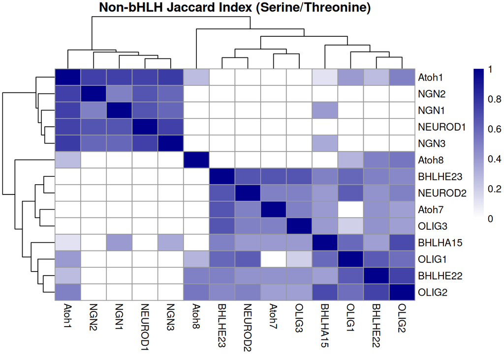

```r
# Load the updated CSV files
jaccard_non_bHLH_SerThr <- read.csv("jaccard_non_bHLH_SerThr_results.csv", stringsAsFactors = FALSE)
jaccard_bHLH_SerThr <- read.csv("jaccard_bHLH_SerThr_results.csv", stringsAsFactors = FALSE)

jaccard_to_matrix <- function(jaccard_df) {
  # Convert the Jaccard index data frame into a square matrix
  unique_genes <- unique(c(jaccard_df$Gene1, jaccard_df$Gene2))

  jaccard_matrix <- matrix(NA, nrow = length(unique_genes), ncol = length(unique_genes),
                           dimnames = list(unique_genes, unique_genes))

  for (i in 1:nrow(jaccard_df)) {
    gene1 <- jaccard_df$Gene1[i]
    gene2 <- jaccard_df$Gene2[i]
    value <- jaccard_df$Jaccard_Index[i]
    jaccard_matrix[gene1, gene2] <- value
    jaccard_matrix[gene2, gene1] <- value
  }

    return(jaccard_matrix)
}

# Convert to matrices
non_bHLH_SerThr_matrix <- jaccard_to_matrix(jaccard_non_bHLH_SerThr)
bHLH_SerThr_matrix <- jaccard_to_matrix(jaccard_bHLH_SerThr)

# Perform clustering
dist_non_bHLH_SerThr <- dist(non_bHLH_SerThr_matrix)
clustering_non_bHLH_SerThr <- hclust(dist_non_bHLH_SerThr)

dist_bHLH_SerThr <- dist(bHLH_SerThr_matrix)
clustering_bHLH_SerThr <- hclust(dist_bHLH_SerThr)

# Plot heatmaps
pheatmap(
  non_bHLH_SerThr_matrix,
  main = "Non-bHLH Jaccard Index (Serine/Threonine)",
  cluster_rows = clustering_non_bHLH_SerThr,
  cluster_cols = clustering_non_bHLH_SerThr,
  color = colorRampPalette(c("white", "darkblue"))(100)
)
```

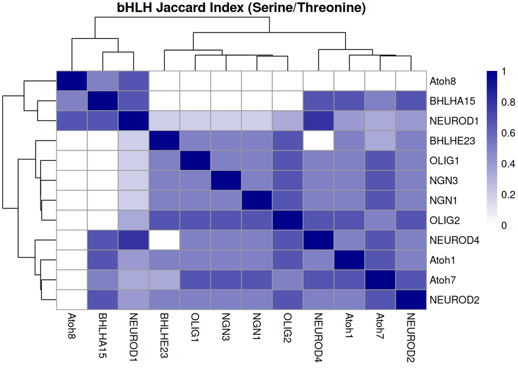

```r
pheatmap(
  bHLH_SerThr_matrix,
  main = "bHLH Jaccard Index (Serine/Threonine)",
  cluster_rows = clustering_bHLH_SerThr,
  cluster_cols = clustering_bHLH_SerThr,
  color = colorRampPalette(c("white", "darkblue"))(100)
)
```

We can also visualize the clusterings made by the Jaccard Index calculation this way:

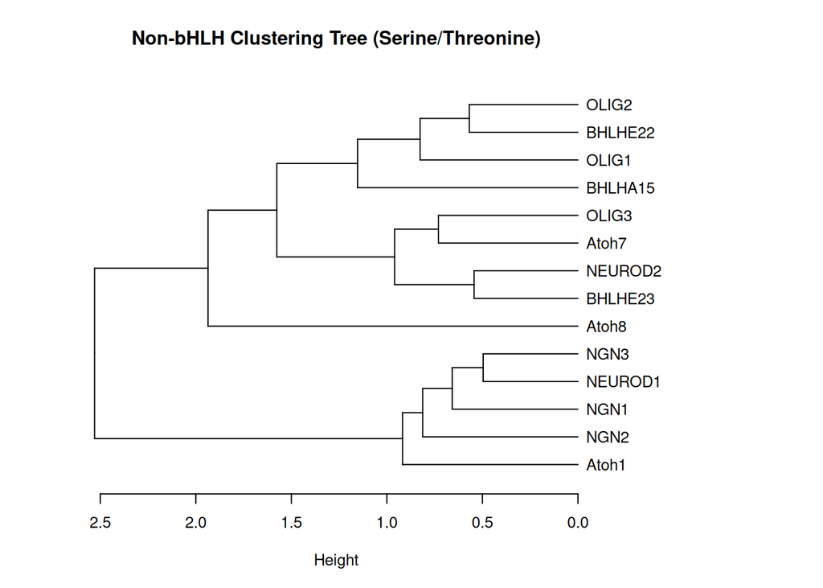

```r
# Plot the dendrogram for non-bHLH Jaccard Index horizontally with adjusted xlim
# Ensure clustering_non_bHLH_SerThr exists and then create dendrogram_non_bHLH
dendrogram_non_bHLH <- as.dendrogram(clustering_non_bHLH_SerThr)
dendrogram_bHLH <- as.dendrogram(clustering_bHLH_SerThr)
# Adjust font size and margins
par(cex = 0.8, mar = c(5, 4, 4, 12))  # Increase label size and adjust right margin

# Plot the dendrogram for non-bHLH Jaccard Index with adjusted branch lengths
plot(
  dendrogram_non_bHLH,
  main = "Non-bHLH Clustering Tree (Serine/Threonine)",
  xlab = "Height",
  horiz = TRUE,
)
```

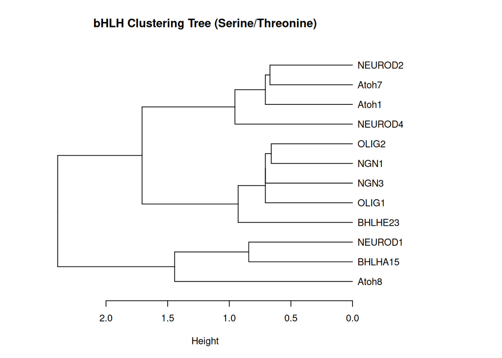

```r
# Adjust font size and margins for bHLH dendrogram
par(cex = 0.8, mar = c(5, 4, 4, 12))  # Increase label size and adjust right margin

# Plot the dendrogram for bHLH Jaccard Index with adjusted branch lengths
plot(
  dendrogram_bHLH,
  main = "bHLH Clustering Tree (Serine/Threonine)",
  xlab = "Height",
  horiz = TRUE,
)
```